# Ejemplo R Markdown v2

Felipe Ortega

03/03/2015

# Introducción

Este es un documento generado mediante el lenguaje de marcado R Mardkown. Se trata de una versión de Markdown, un lenguaje de marcado ligero que se ha popularizado enormemente. R Markdown adapta este lenguaje de marcado para facitilar la inserción de código R, así como el producto de su ejecución (resultados numéricos, tablas, gráficos, etc.). De este modo, constituye un ejemplo de [programación literaria](http://www.literateprogramming.com/).

La sintaxis de R Markdown permite utilizar un solo tipo de archivo fuente para generar múltiples formatos de salida: HTML, PDF o documentos MS Word. Se puede encontrar una descripción más detallada en http://rmarkdown.rstudio.com. Este documento describe R Markdown v2, la versión más actual hasta la fecha (marzo 2015).

A partir de la versión 0.98 de RStudio, cuando creamos o editamos un documento R Markdwon la barra de herramientas del área de edición muestra un botón **Knit** que ofrece varias opciones, dependiendo del tipo de documento de salida que pretendamos generar.

## Contenidos

1. Instalación de R y RStudio (si fuese necesario).
2. Introducir los elementos básicos de sintaxis (Markdown).
3. Creación de *chunks* para insertar código en R, y opciones disponibles.
4. Insertar elementos adicionales, tales como tablas o ecuaciones.
5. Insertar referencias.

# Instalación de R y RStudio

Para trabajar con R Markdown, realizar los pasos que sean necesarios de la siguiente lista:

- Instalar [R](http://www.r-project.org/)
- Instalar la última versión de [RStudio](http://rstudio.org/download/) (actualmente 0.98).
- Instalar la versión más reciente del paquete R `knitr`: `install.packages("knitr")`

A continuación, para crear un nuevo documento R Markdown realizar los siguientes pasos:

- Abrir R Studio y pulsar **File** -> **New File** -> **R Markdown…**
- Seleccionar el tipo de archivo (**Document**), rellenar los datos (opcional) y pular **OK**.
- Escribir el contenido del documento según las normas de sintaxis establecidas en http://rmarkdown.rstudio.com/authoring_basics.html.
- Pulsar **Knit HTML**. Si no hay errores, RStudio concluirá la construcción del fichero HTML a mostrar y abrirá un pequeño navegador integrado en el propio IDE para visualizar el resultado.

Existe también un [esquema de referencia](http://rmarkdown.rstudio.com/RMarkdownCheatSheet.pdf) que resume los distintos pasos de este procedimiento.

# Sintaxis para elementos básicos (Markdown)

Como ya se ha indicado, Markdown permite la creación de elementos comunes en creación y edición de documentos (resaltado de fuente, listas, encabezados, etc.). Los detalles se pueden encontrar en http://rmarkdown.rstudio.com/authoring_basics.html.

A veces, el lenguaje también soporta **directivas específicas** para determinados formatos de documentos de salida (por ejemplo, directivas de LaTeX para generar un PDF). Sin embargo, puede que estas directivas no funcionen para otros formatos de documentos. Por eso, es mejor intentar evitarlas salvo que estemos seguros de que únicamente generaremos ese tipo de archivo.

Aunque está fuera del ámbito de este pequeño ejemplo, es importante resaltar que R Markdown v2 también integra métodos para generar **otros tipos de ficheros** de presentación, además de documentos. Por ejemplo, existen plantillas para crear [presentaciones HTML 5](http://rmarkdown.rstudio.com/ioslides_presentation_format.html), que podremos visualizar directamente en cualquier navegador web moderno.

Igualmente, existe la opción de crear rápidamente **interfaces web interactivas** mediante [Shiny](http://shiny.rstudio.com/), utilizando la misma sintaxis de R Markdown. Todas estas opciones hacen de R Markdown una herramienta muy versátil para documentación de análisis de datos, facilitando su reproducción y edición.

# Creación de *chunks* para código en R

Existen múltiples opciones para modificar el comportamiento de un *chunk*. Podemos pulsar la tecla `Tab` dentro de las llaves (a continuación de `r`) para que aparezca un listado de todas las opciones. Algunas de las más relevantes son:

- Nombrar un *chunk* (para hacer referencia en el documento y también para organizar mejor nuestro contenido):  
  `{r nombre_chunk}`
- No mostrar la el código R de entrada en el documento:  
  `{r echo=FALSE}`
- Mostrar el contenido del chunk directamente como código:  
  `{r echo=FALSE results='asis'}`
- No ejecutar el código de R suministrado:  
  `{r eval=FALSE}`

Algunos ejemplos:

```r
x <- 1:10
y <- round(rbeta(10, x, 1), 2)
df <- data.frame(x, y)
df
```

```
##     x    y
## 1   1 0.39
## 2   2 0.99
## 3   3 0.88
## 4   4 0.83
## 5   5 0.78
## 6   6 0.94
## 7   7 0.79
## 8   8 0.97
## 9   9 0.95
## 10 10 0.85
```

# Elementos adicionales

## Figuras

Insertar figuras es bastante sencillo:

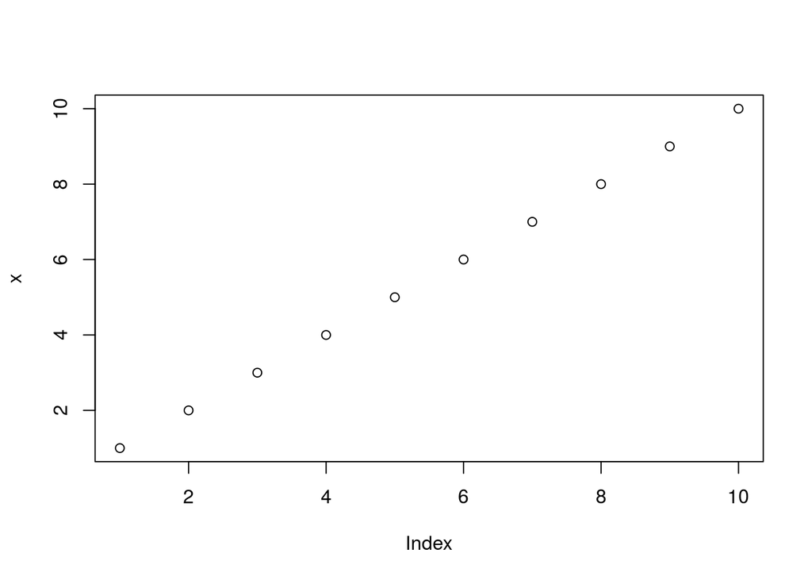

```r
plot(x)  # Sin opciones
```

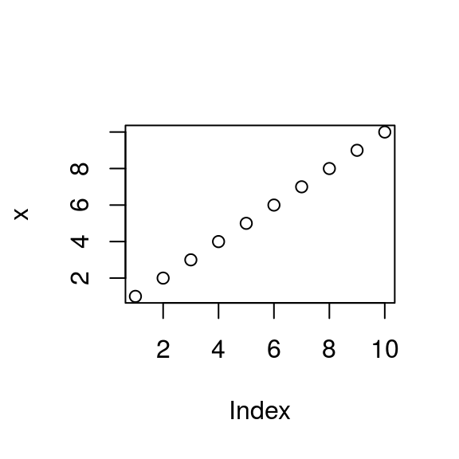

```r
plot(x)  # Opciones chunk fig.width=3, fig.height=3
```

Por supuesto, también funcionan los paquetes de visualización más avanzados, como `lattice` o `ggplot2`.

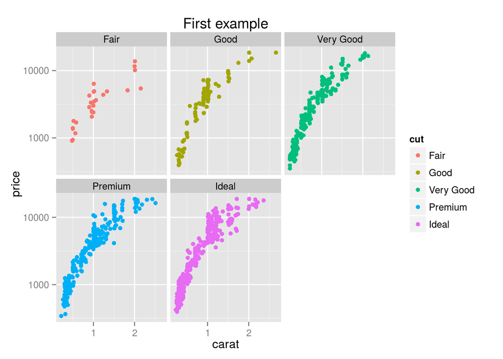

```r
library(ggplot2)
set.seed(42) # Reproducible
small<-diamonds[sample(nrow(diamonds),1000),]
ggplot(small) +
  geom_point(aes(x=carat,y=price,colour=cut)) +
    scale_y_log10() +
      facet_wrap(~cut) +
        ggtitle("First example")
```

## Tablas

| A | B | C |
| --- | --- | --- |
| 1 | Male | 50 |
| 2 | Female | 45 |

## Ecuaciones

Para insertar ecuaciones debemos utilizar la misma notación que se emplea en los documentos LaTeX. No es complicada, pero requiere una cierta curva de aprendizaje.

Tenemos dos opciones. La primera es mostrar la ecuación en línea con el resto del contenido: $y_i = \alpha + \beta_0 x_0i + \beta_1 x_1i + e_i$.

La segunda opción es el modo *display* (muestra la ecuación de forma independiente, modificando la presentación de ciertos símbolos como sumatorios, integrales o fracciones).

$\lim_{x\to\infty}\frac{x}{x+1}$

$\frac{1}{1+\exp(-3x+2)}$

**Importante**: Para ver correctamente las ecuaciones es necesario visualizar el documento HTML5 en un navegador externo, en lugar de usar el navegador integrado en RStudio. Esto se debe a que utiliza una biblioteca llamada Mathjax para renderizar las fórmulas. Por esta razón, también es imprescindible estar conectado a Internet (de forma que nuestro documento pueda cargar el script de Mathjax al renderizar la página en el navegador).

## Imágenes

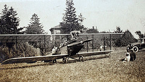

# Cómo insertar referencias

Se pueden insertar enlaces internos (a otras partes del documento)[1] o también referencias bibliográficas(Fenner 2012). En este caso, hemos insertado los datos de la entrada bibliográfica directamente en los metadatos del encabezado de nuestro documento (sección `references:`). Por supuesto, también podemos proporcionar un fichero externo con todas las referencias clasificadas en los formatos más comunes (BibTex, EndNote, etc.).

**Importante**: La relación de referencias bibliográficas se insertará automáticamente al final de nuestro documento. Sin embargo, *no se añade automáticamente un encabezado*. Por eso, debemos recordar añadirlo nosotros al final del documento.

# Recursos adicionales

- http://rmarkdown.rstudio.com/
- RPubs: servicio de [publicación de R Markdown](https://rpubs.com/) (RStudio).
- Libro: Investigación reproducible con R y RStudio (Gandrud 2013).

### Notas

[1] Este es un ejemplo de nota a pie de página.

Referencias

Fenner, Martin. 2012. “One-Click Science Marketing.” *Nature Materials* 11 (4) (March): 261. doi:10.1038. http://dx.doi.org/10.1038/nmat3283.

Gandrud, Christopher. 2013. *Reproducible Research with R and R Studio*. CRC Press.